# Table of Content:

# 0. Introduction

# 1. Business Problem

# 2. Importing libraries and loading the data

## 2.1 Importing and Interpreting the use of libraries

**Pandas** is flexible, fast and easy to use open source data analysis and manipulation tool.  
**Numpy** is python library used to perform mathematical operations on array.  
**matplotlib** and **seaborn** are python libraries used for data visualization. We can visualize data by charts and plots.  
**sklearn** is used for machine learning and statistical modeling including classification, regression, clustering and dimensionality reduction.

```python
import pandas as pd
import numpy as np

# Libraries for plotting and visualization
import matplotlib.pyplot as plt
import seaborn as sns

# libraries for modeling
from lightgbm import LGBMClassifier
from sklearn.preprocessing import RobustScaler
from sklearn.model_selection import train_test_split,cross_val_score,GridSearchCV,RandomizedSearchCV
from sklearn.metrics import confusion_matrix, classification_report
from sklearn.tree import DecisionTreeClassifier
from sklearn.ensemble import RandomForestClassifier

import time
import warnings
warnings.filterwarnings(action='ignore')
```

## 2.2 Loading the data and looking at sample of 5 rows

### Fields overview:

**Static Informations:**

Static Information is provided by the subject vessel’s crew and is transmitted every 6 minutes regardless of the vessel’s movement status

- 1 - mmsi : a unique identification number for each vessel station (the vessel’s flag can also be deducted from it)
- 2 - shiptype : ship’s type (tanker, cargo, fishing etc)
- 3 - width : width of vessel
- 4 - length : length of vessel
- 5 - draught : draught of vessel (the vertical distance between the waterline and the bottom of the hull (keel))

**Dynamic Informations:**

Dinamic Informations automatically transmitted every 2 to 10 seconds depending on the vessel’s speed and course while underway and every 6 minutes while anchored from vessels

- 6 - navigationalstatus : instant situation (navigating, mooored etc)
- 7 - sog : speed of ground
- 8 - cog : course of ground (0 to 359 degrees)
- 9 - heading : fore side (heading and cog are not same because of the wind, current. But they are close to each other)

**Data Source:** https://www.kaggle.com/code/eminserkanerdonmez/ai-in-maritime-industsy/data

```python
#loading the dataset
df = pd.read_csv('ais_data.csv').drop('Unnamed: 0', axis=1)

# check the size of the dataset using shape
print("size of the dataset:",df.shape)

print("\nLook at 1st 5 rows in the data:")
df.head()
```

```
size of the dataset: (358351, 9)

Look at 1st 5 rows in the data:
```

|  | mmsi | navigationalstatus | sog | cog | heading | shiptype | width | length | draught |
| --- | --- | --- | --- | --- | --- | --- | --- | --- | --- |
| 0 | 219019621 | Unknown value | 0.0 | 86.0 | 86.0 | Fishing | 4.0 | 9.0 | NaN |
| 1 | 265628170 | Unknown value | 0.0 | 334.5 | NaN | Port tender | 8.0 | 27.0 | NaN |
| 2 | 219005719 | Unknown value | 0.0 | 208.7 | NaN | Fishing | 4.0 | 11.0 | NaN |
| 3 | 219028066 | Unknown value | 0.0 | NaN | NaN | Pleasure | 3.0 | 12.0 | NaN |
| 4 | 212584000 | Moored | 0.0 | 153.0 | 106.0 | Cargo | 13.0 | 99.0 | 6.3 |

```python
#Get information for the dataset such as datatype and non null counts
df.info()
```

```
<class 'pandas.core.frame.DataFrame'>
RangeIndex: 358351 entries, 0 to 358350
Data columns (total 9 columns):
 #   Column              Non-Null Count   Dtype
---  ------              --------------   -----
 0   mmsi                358351 non-null  int64
 1   navigationalstatus  358351 non-null  object
 2   sog                 357893 non-null  float64
 3   cog                 355182 non-null  float64
 4   heading             337737 non-null  float64
 5   shiptype            358351 non-null  object
 6   width               354640 non-null  float64
 7   length              354608 non-null  float64
 8   draught             332808 non-null  float64
dtypes: float64(6), int64(1), object(2)
memory usage: 24.6+ MB
```

#### Data has total 9 columns with 7 being numerical and categorical.

**Numerical columns:** mmsi, sog, cog, heading, width, length & draught  
**Categorical columns:** navigationalstatus & shiptype

# 3. EDA - EXPLORATORY DATA ANALYSIS

## 3.1. Missing value information

```python
pd.options.display.float_format = "{:,.3f}".format

def missing_values_table(df):
    m=df.isnull().sum()
    print(pd.DataFrame({'n_miss' : m[m!=0],'% of total count' : m[m!=0]/len(df)}))

missing_values_table(df)
```

```
         n_miss  % of total count
sog         458             0.001
cog        3169             0.009
heading   20614             0.058
width      3711             0.010
length     3743             0.010
draught   25543             0.071
```

Column **draught** has ~7.1% and **heading** has ~5.7% missing values.  
**width** and **length** each has around 1% missing values.

## 3.2. Numerical columns

### 1. Summary statistics for Numerical columns

```python
pd.options.display.float_format = "{:,.2f}".format
num_cols = ['mmsi','sog','cog','heading','width','length','draught']

df[num_cols].describe()
```

|  | mmsi | sog | cog | heading | width | length | draught |
| --- | --- | --- | --- | --- | --- | --- | --- |
| count | 358,351.00 | 357,893.00 | 355,182.00 | 337,737.00 | 354,640.00 | 354,608.00 | 332,808.00 |
| mean | 293,967,827.62 | 12.12 | 189.06 | 190.08 | 19.95 | 124.97 | 6.57 |
| std | 121,386,631.12 | 9.36 | 107.59 | 107.11 | 10.81 | 71.27 | 2.93 |
| min | 9,112,856.00 | 0.00 | 0.00 | 0.00 | 1.00 | 2.00 | 0.40 |
| 25% | 219,578,000.00 | 9.20 | 116.30 | 120.00 | 12.00 | 83.00 | 4.60 |
| 50% | 248,659,000.00 | 11.30 | 168.70 | 170.00 | 17.00 | 115.00 | 6.10 |
| 75% | 304,665,000.00 | 13.30 | 300.18 | 303.00 | 28.00 | 181.00 | 7.90 |
| max | 992,195,011.00 | 214.00 | 359.90 | 507.00 | 78.00 | 690.00 | 25.50 |

### 2. Distribution of values for numerical columns

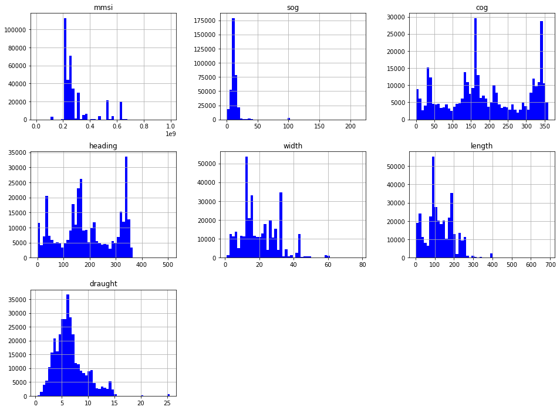

```python
dummy = df[num_cols].hist(bins=50, figsize=(16,12), color = "blue")
```

### 3. Frequency distribution and Box-Plot

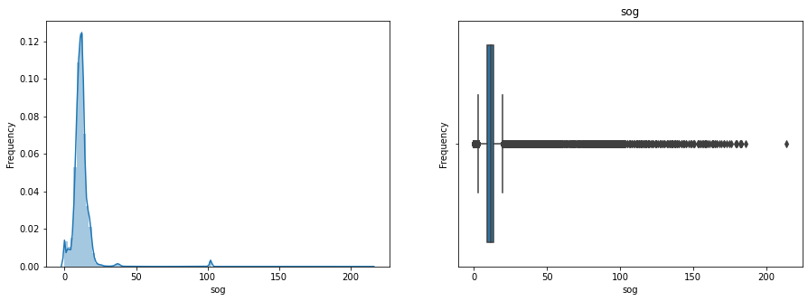

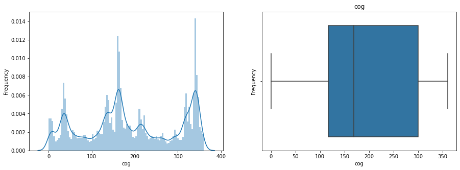

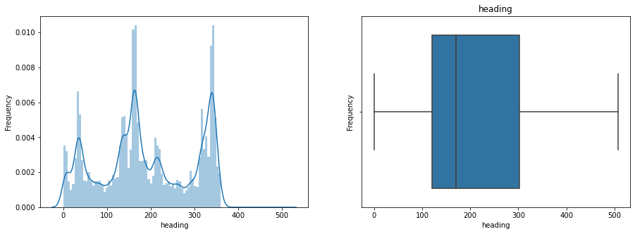

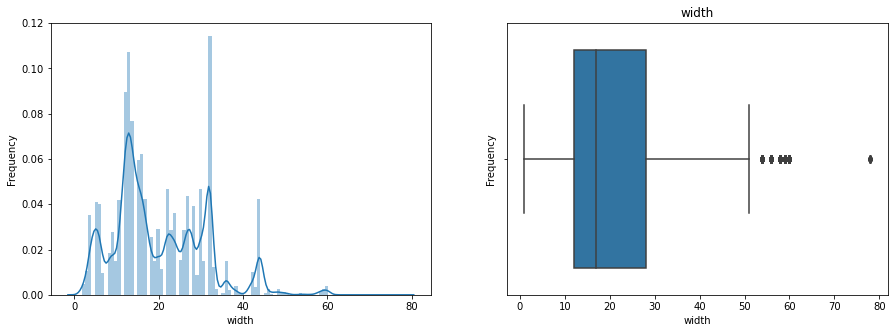

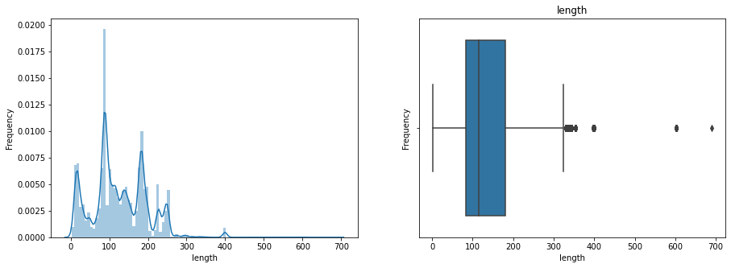

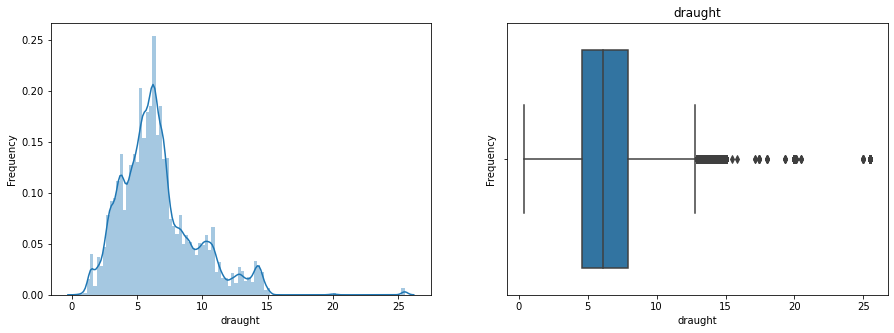

```python
col_list = ['sog', 'cog', 'heading','width', 'length', 'draught']

for col in col_list:
    fig = plt.figure(figsize = (15,5))
    #Histogram
    plt.subplot(1,2,1)
    #Define plot object
    hist = sns.distplot(df.loc[:,col].astype(float), bins = 100)
    #Setting graph title
    #hist.set_title(col)
    hist.set(xlabel = col, ylabel = 'Frequency')
    #Boxplot
    plt.subplot(1,2,2)
    #Define plot object
    box = sns.boxplot(df.loc[:,col].astype(float))
    #Setting graph title
    box.set_title(col)
    box.set(xlabel = col, ylabel = 'Frequency')
    #Showing the plot
    plt.show()
```

As per the box-plot method, there are a bunch of outliers in "sog" and few in "width", "length" and "draught".  
"cog" and "heading" does not seem to have any outliers.

## 3.3. Distribution of values for categorical columns

```
% Distribution of Navigational Status:

Under way using engine                                  0.86
Unknown value                                           0.05
Constrained by her draught                              0.03
Engaged in fishing                                      0.03
Moored                                                  0.01
Reserved for future amendment [HSC]                     0.01
Restricted maneuverability                              0.01
Under way sailing                                       0.00
At anchor                                               0.00
Power-driven vessel towing astern                       0.00
Power-driven vessel pushing ahead or towing alongside   0.00
Not under command                                       0.00
Reserved for future amendment [WIG]                     0.00
Name: navigationalstatus, dtype: float64
```

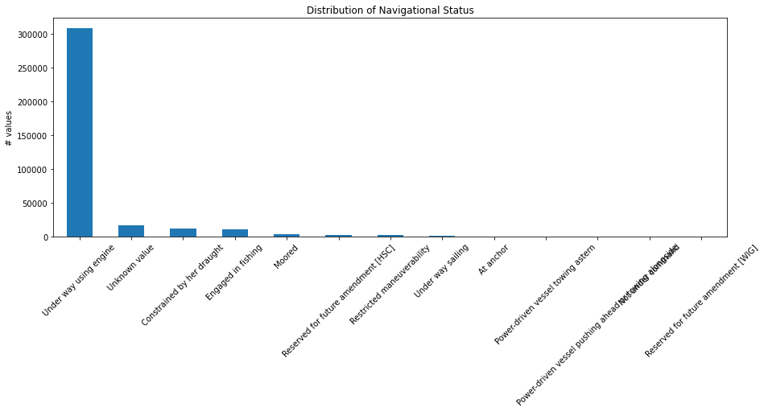

```python
# Distribution of column "navigationalstatus"

print('% Distribution of Navigational Status:\n')
print(df['navigationalstatus'].value_counts(1))

print('\n\n')
plt.figure(figsize=(15,5))
df['navigationalstatus'].value_counts().plot.bar()
plt.title('Distribution of Navigational Status')
plt.ylabel('# values')
plt.xticks(rotation = 45)
plt.show()
```

The value **Under way using engine** contributes to 86% of the total data in column "navigationalstatus". While **Unknown values** makes up 5%.

```
% Distribution of Ship Type:

Cargo              0.53
Tanker             0.22
Fishing            0.07
Passenger          0.05
Tug                0.03
Military           0.02
Dredging           0.02
Pleasure           0.01
SAR                0.01
Pilot              0.01
HSC                0.01
Sailing            0.01
Law enforcement    0.00
Towing             0.00
Reserved           0.00
Towing long/wide   0.00
Port tender        0.00
Name: shiptype, dtype: float64
```

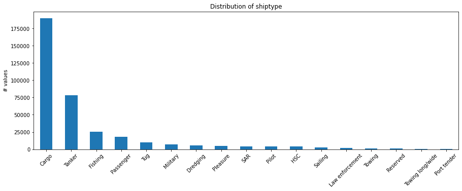

```python
# Distribution of column "shiptype"

print('% Distribution of Ship Type:\n')
print(df['shiptype'].value_counts(1))

print('\n\n')
plt.figure(figsize=(15,5))
df['shiptype'].value_counts().plot.bar()
plt.title('Distribution of shiptype')
plt.ylabel('# values')
plt.xticks(rotation = 45)
plt.show()
```

## 3.4. Outlier detection using Box-Plot method

```python
def thresholds(col, data, d, u):
    q3=data[col].quantile(u)
    q1=data[col].quantile(d)
    down=q1-(q3-q1)*1.5
    up=q1+(q3-q1)*1.5
    return down, up

def check_outliers(col, data, d=0.25, u=0.75, plot=False):
    down, up = thresholds(col, data, d, u)
    ind = data[(data[col] < down) | (data[col] > up)].index
    if plot:
        sns.boxplot(x=col, data=data)
        plt.show()
    if len(ind)!= 0:
        print(f"\n Number of outliers for '{col}' : {len(ind)}")
        return col

for col in num_cols:
    check_outliers(col, df, 0.01, 0.99) # we set thresholds at 0.01 and 0.99
```

```
 Number of outliers for 'mmsi' : 24

 Number of outliers for 'sog' : 2910

 Number of outliers for 'width' : 9

 Number of outliers for 'length' : 47

 Number of outliers for 'draught' : 567
```

## 3.5. Correlation Matrix between numerical columns

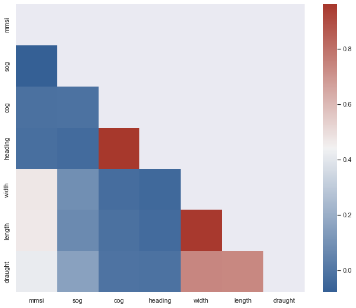

```python
# correlation matrix dataframe
df_corr = df[num_cols].corr()

### Heat map of correlation matrix
sns.set_theme(style="darkgrid")

mask = np.triu(np.ones_like(df_corr))
f, ax = plt.subplots(figsize=(11, 9))
cmap = sns.diverging_palette(250, 15, s=75, l=40, center="light", as_cmap=True)

# Draw the heatmap with the mask and correct aspect ratio
sns.heatmap(df_corr, mask=mask, cmap=cmap, square=True)
plt.show()
```

**heading** is highly related to **cog** (96% correlation).  
Similary, **width** also has a 96% correlation with **length**  
**draught** has 74% correlation with both **lenght** and **width**

## 3.6 Average length and width by shiptype

```python
df[['mmsi','shiptype','length','width']].drop_duplicates(subset='mmsi')\
                                        .groupby(['shiptype'])\
                                        .agg({'width':'mean','length':'mean'})\
                                        .reset_index()\
                                        .sort_values('width')
```

|  | shiptype | width | length |
| --- | --- | --- | --- |
| 11 | SAR | 2.88 | 9.20 |
| 8 | Pleasure | 3.75 | 11.30 |
| 12 | Sailing | 4.06 | 13.66 |
| 9 | Port tender | 4.78 | 14.00 |
| 7 | Pilot | 5.10 | 16.79 |
| 4 | Law enforcement | 5.94 | 24.22 |
| 2 | Fishing | 6.03 | 22.37 |
| 14 | Towing | 7.45 | 22.82 |
| 15 | Towing long/wide | 9.00 | 28.33 |
| 5 | Military | 9.29 | 50.75 |
| 16 | Tug | 10.58 | 35.23 |
| 10 | Reserved | 11.92 | 44.08 |
| 1 | Dredging | 12.38 | 61.28 |
| 3 | HSC | 13.20 | 45.68 |
| 6 | Passenger | 16.75 | 90.51 |
| 0 | Cargo | 21.57 | 144.02 |
| 13 | Tanker | 28.75 | 174.91 |

There seems to have a clear distinction between dimensions of the ship (length & widht) for different ship types.  
These might be strong predictors in the model for "shiptype".

# 4. FEATURE ENGINEERING

## 4.1. Creating new features

1. ‘cog’ and ‘heading’ variables are very similar. And they also have a high correlation of 96% between them. So we can combine these two as one.
2. Dividing the 360-degree route into 8 regions.
3. the ships with less than 5.5kts speed and no route information were tagged as 'FIX'.
4. Vessels’ speed depends on ship type mostly. We fill the missings according to 'sog' and 'route' variables. Then assigned as a new variable "speed"
5. new variables dimension = widht*length

```python
# First, the filling was made according to those in the 'heading' but not in the 'cog'.
df['cog'] = np.where(df['cog'].isnull(), df['heading'], df['cog'])

# Secondly, we divided the 360-degree route into 8 regions.
rot= [-1, 45, 90, 135, 180, 225, 270, 315, 360]
df['waypoint'] = pd.cut(df['cog'], rot, labels=['NNE','ENE','ESE','SSE','SSW','WSW','WNW','NNW'])

# Finally, the ships with less than 5.5kts speed and no route information were tagged as 'FIX'.
df['waypoint'] = np.where((df['sog']<5.5) & (df['waypoint'].isnull()), 'FIX', df['waypoint'])

# Filling the missings according to 'sog' and 'cog' variables. Then assigned as a new variable "speed".
df['speed'] = df["sog"].fillna(df.groupby(['shiptype', 'waypoint'])['sog'].transform('mean'))

# dimension = lenght*width
df['dimension'] = df['width'] * df['length']
```

## 4.2. Dropping features not required for modeling and deduping

```python
# columns to drop
drop_cols = ['mmsi','heading']

# new df_m for modeling data only
df_m = df.drop(drop_cols, axis=1).drop_duplicates()

print('shape modeling data after dropping columns and deduping', df_m.shape)
```

```
shape modeling data after dropping columns and deduping (348379, 10)
```

## 4.3. Filling missing values with median for numerical features and mode for categorical

```python
# filling waypoint with mode
df_m['waypoint'] = df_m['waypoint'].fillna(df_m['waypoint'].mode()[0])

# filling numerical with median
df_m = df_m.fillna(df_m.median(numeric_only=True))
```

# 5. OHE - one-hot encoding for categorical features

#### Only "navigationalstatus" and "waypoint" will be encoded and shiptype since shiptype is the model target

```python
# One hot encoder function;
def one_hot_encoder(df, cat_cols, drop_first=True):
    dataframe = pd.get_dummies(df, columns=cat_cols, drop_first=drop_first)
    return dataframe
```

```python
df_m = one_hot_encoder(df_m, cat_cols=['waypoint','navigationalstatus'], drop_first=True)
df_m
```

|  | sog | cog | shiptype | width | length | draught | speed | dimension | waypoint_ESE | waypoint_FIX | ... | navigationalstatus_Moored | navigationalstatus_Not under command | navigationalstatus_Power-driven vessel pushing ahead or towing alongside | navigationalstatus_Power-driven vessel towing astern | navigationalstatus_Reserved for future amendment [HSC] | navigationalstatus_Reserved for future amendment [WIG] | navigationalstatus_Restricted maneuverability | navigationalstatus_Under way sailing | navigationalstatus_Under way using engine | navigationalstatus_Unknown value |
| --- | --- | --- | --- | --- | --- | --- | --- | --- | --- | --- | --- | --- | --- | --- | --- | --- | --- | --- | --- | --- | --- |
| 0 | 0.00 | 86.00 | Fishing | 4.00 | 9.00 | 6.10 | 0.00 | 36.00 | 0 | 0 | ... | 0 | 0 | 0 | 0 | 0 | 0 | 0 | 0 | 0 | 1 |
| 1 | 0.00 | 334.50 | Port tender | 8.00 | 27.00 | 6.10 | 0.00 | 216.00 | 0 | 0 | ... | 0 | 0 | 0 | 0 | 0 | 0 | 0 | 0 | 0 | 1 |
| 2 | 0.00 | 208.70 | Fishing | 4.00 | 11.00 | 6.10 | 0.00 | 44.00 | 0 | 0 | ... | 0 | 0 | 0 | 0 | 0 | 0 | 0 | 0 | 0 | 1 |
| 3 | 0.00 | 169.00 | Pleasure | 3.00 | 12.00 | 6.10 | 0.00 | 36.00 | 0 | 1 | ... | 0 | 0 | 0 | 0 | 0 | 0 | 0 | 0 | 0 | 1 |
| 4 | 0.00 | 153.00 | Cargo | 13.00 | 99.00 | 6.30 | 0.00 | 1,287.00 | 0 | 0 | ... | 1 | 0 | 0 | 0 | 0 | 0 | 0 | 0 | 0 | 0 |
| ... | ... | ... | ... | ... | ... | ... | ... | ... | ... | ... | ... | ... | ... | ... | ... | ... | ... | ... | ... | ... | ... |
| 358346 | 11.00 | 171.90 | Cargo | 12.00 | 82.00 | 4.20 | 11.00 | 984.00 | 0 | 0 | ... | 0 | 0 | 0 | 0 | 0 | 0 | 0 | 0 | 1 | 0 |
| 358347 | 16.60 | 341.60 | Cargo | 27.00 | 170.00 | 8.90 | 16.60 | 4,590.00 | 0 | 0 | ... | 0 | 0 | 0 | 0 | 0 | 0 | 0 | 0 | 1 | 0 |
| 358348 | 20.60 | 340.70 | Passenger | 36.00 | 224.00 | 6.90 | 20.60 | 8,064.00 | 0 | 0 | ... | 0 | 0 | 0 | 0 | 0 | 0 | 0 | 0 | 1 | 0 |
| 358349 | 34.90 | 96.20 | Pilot | 3.00 | 7.00 | 6.10 | 34.90 | 21.00 | 1 | 0 | ... | 0 | 0 | 0 | 0 | 0 | 0 | 0 | 0 | 0 | 1 |
| 358350 | 11.50 | 315.00 | Fishing | 8.00 | 32.00 | 6.00 | 11.50 | 256.00 | 0 | 0 | ... | 0 | 0 | 0 | 0 | 0 | 0 | 0 | 0 | 1 | 0 |

348379 rows × 28 columns

```python
df_m.rename(columns={"navigationalstatus_Reserved for future amendment [HSC]":"navigationalstatus_Reserved for future amendment_HSC"}, inplace=True)
df_m.rename(columns={"navigationalstatus_Reserved for future amendment [WIG]":"navigationalstatus_Reserved for future amendment_WIG"}, inplace=True)
```

# 6. Data-Splitting

#### Splitting the data into train and test for modelling

#### Train 80% and Test 20%

### 6.1 Feature and Target split

```python
target = 'shiptype'

X = df_m.drop(target, axis=1)
y = df_m[target]
```

### 6.2 Train-Test split

```python
X_train, X_test, y_train, y_test = train_test_split(X, y, train_size=0.8, random_state=7)
```

## 6.3 Scaling the features - Robust Scaler

#### 'RobustScaler' is used because it is robust to outliers

```python
# RobustScaler object - fitting on train
scaler = RobustScaler()
scaler.fit(X_train)

# transforming X_train
X_train = pd.DataFrame(scaler.transform(X_train), columns=X_train.columns)

# transforming X_test
X_test = pd.DataFrame(scaler.transform(X_test), columns=X_test.columns)
```

# 7. Modeling and evaluation

1) First, a baseline model will be built where the prediction will be the most common class in the target.  
2) Then some multi-class classifier models will be built with default parameters and without any hyper-parameter tuning.  
3) Best performing model from step 2 will be picked and further fine-tuned.

```python
## Function to plot feature importance
def show_feat_imp(model, X, n_feats=15):
    """
    model: model object
    X: feature dataset on which prediction is to be done. Ex: X_test or X_train
    n_feats: number of top features to display
    """
    feat_imp = pd.Series(model.feature_importances_, index = X.columns).sort_values(ascending = False)
    display(feat_imp.head(n_feats))
    feat_imp.head(n_feats).plot.bar(x='features', y='feat_imp', figsize=(15,8), align="center")
```

## 7.1 Baseline Model

Here, we use a majority class classifier as a baseline i.e we find the most common class amongst the data set where the output is always a prediction

```python
# majority class - mode of shiptype
y_mode = y_train.mode()[0]
print('majority category for shiptype:', y_mode)
```

```
majority category for shiptype: Cargo
```

The baseline method will present "Cargo" as output for all predictions. We can use macro-averaging in this project (precision, recall and F-score are evaluated in each class separately and then averaged across classes).

So if we apply the baseline classifier to all of the training set for the "Cargo" label, the accuracy measures will be:

```python
# prediction using mode
prediction = np.repeat(y_mode, y_test.shape[0])
```

```python
# performance of baseline model on test
print(classification_report(y_test,prediction))
```

```
                  precision    recall  f1-score   support

           Cargo       0.54      1.00      0.70     37524
        Dredging       0.00      0.00      0.00      1062
         Fishing       0.00      0.00      0.00      4986
             HSC       0.00      0.00      0.00       709
 Law enforcement       0.00      0.00      0.00       320
        Military       0.00      0.00      0.00      1416
       Passenger       0.00      0.00      0.00      3298
           Pilot       0.00      0.00      0.00       789
        Pleasure       0.00      0.00      0.00       625
     Port tender       0.00      0.00      0.00        57
        Reserved       0.00      0.00      0.00       144
             SAR       0.00      0.00      0.00       709
         Sailing       0.00      0.00      0.00       370
          Tanker       0.00      0.00      0.00     15452
          Towing       0.00      0.00      0.00       208
Towing long/wide       0.00      0.00      0.00       122
             Tug       0.00      0.00      0.00      1885

        accuracy                           0.54     69676
       macro avg       0.03      0.06      0.04     69676
    weighted avg       0.29      0.54      0.38     69676
```

#### The accuracy of baseline model is at 54%. It can definitely be improved.

## 7.2 Decision Tree Classifier

```python
# decision tree classifier object
dt = DecisionTreeClassifier(random_state=7)
dt.fit(X_train, y_train)

# Prediction on test
dt_pred = dt.predict(X_test)

# performance of decision tree classifier on test
print(classification_report(y_test,dt_pred))
```

```
                  precision    recall  f1-score   support

           Cargo       0.99      0.99      0.99     37524
        Dredging       0.97      0.97      0.97      1062
         Fishing       0.96      0.96      0.96      4986
             HSC       0.99      0.98      0.99       709
 Law enforcement       0.98      0.98      0.98       320
        Military       0.99      0.99      0.99      1416
       Passenger       0.99      0.99      0.99      3298
           Pilot       0.96      0.98      0.97       789
        Pleasure       0.65      0.62      0.64       625
     Port tender       0.66      0.72      0.69        57
        Reserved       0.92      0.90      0.91       144
             SAR       0.89      0.90      0.89       709
         Sailing       0.59      0.61      0.60       370
          Tanker       0.98      0.98      0.98     15452
          Towing       0.90      0.91      0.91       208
Towing long/wide       0.96      0.95      0.95       122
             Tug       0.99      0.99      0.99      1885

        accuracy                           0.98     69676
       macro avg       0.90      0.91      0.91     69676
    weighted avg       0.98      0.98      0.98     69676
```

Accuracy of the model is **98%** which is quite good for a simple decision tree.

```
length                                          0.37
dimension                                       0.24
draught                                         0.16
width                                           0.08
speed                                           0.04
cog                                             0.03
sog                                             0.03
navigationalstatus_Engaged in fishing           0.02
navigationalstatus_Under way using engine       0.01
navigationalstatus_Restricted maneuverability   0.00
navigationalstatus_Unknown value                0.00
waypoint_SSE                                    0.00
waypoint_SSW                                    0.00
waypoint_ESE                                    0.00
waypoint_WSW                                    0.00
dtype: float64
```

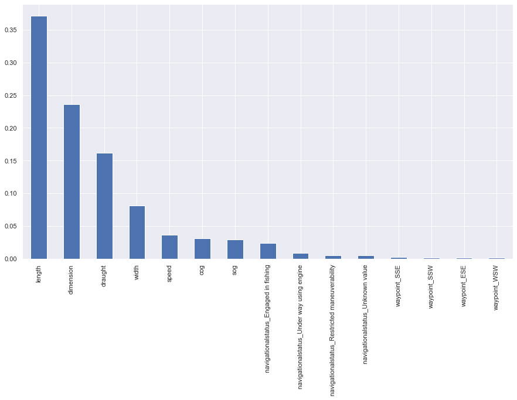

```python
# feature importance
show_feat_imp(model=dt, X=X_test)
```

Top features are "length" and "dimension" contributing almost 60%. This indicates that different ship types have significantly varying sizes/dimensions.

## 7.3 Random Forest Classifier

```python
# random forest classifier object
rf = RandomForestClassifier()
rf.fit(X_train, y_train)

# Prediction on test
rf_pred = rf.predict(X_test)

# performance of random forest classifier on test
print(classification_report(y_test, rf_pred))
```

```
                  precision    recall  f1-score   support

           Cargo       0.99      0.99      0.99     37524
        Dredging       0.98      0.96      0.97      1062
         Fishing       0.96      0.97      0.97      4986
             HSC       1.00      0.99      0.99       709
 Law enforcement       0.99      0.98      0.99       320
        Military       0.99      0.98      0.98      1416
       Passenger       0.99      0.99      0.99      3298
           Pilot       0.97      0.98      0.97       789
        Pleasure       0.68      0.65      0.66       625
     Port tender       0.76      0.74      0.75        57
        Reserved       0.90      0.90      0.90       144
             SAR       0.92      0.90      0.91       709
         Sailing       0.62      0.64      0.62       370
          Tanker       0.99      0.97      0.98     15452
          Towing       0.91      0.91      0.91       208
Towing long/wide       0.97      0.91      0.94       122
             Tug       0.99      0.99      0.99      1885

        accuracy                           0.98     69676
       macro avg       0.92      0.91      0.91     69676
    weighted avg       0.98      0.98      0.98     69676
```

Random forest has similar performance like decision tree with **98%** accuracy on test set.

```
length                                                 0.24
dimension                                              0.23
width                                                  0.14
draught                                                0.14
sog                                                    0.06
speed                                                  0.06
cog                                                    0.05
navigationalstatus_Engaged in fishing                  0.02
navigationalstatus_Under way using engine              0.02
navigationalstatus_Unknown value                       0.01
waypoint_SSE                                           0.00
waypoint_ESE                                           0.00
waypoint_NNW                                           0.00
navigationalstatus_Reserved for future amendment_HSC   0.00
waypoint_WSW                                           0.00
dtype: float64
```

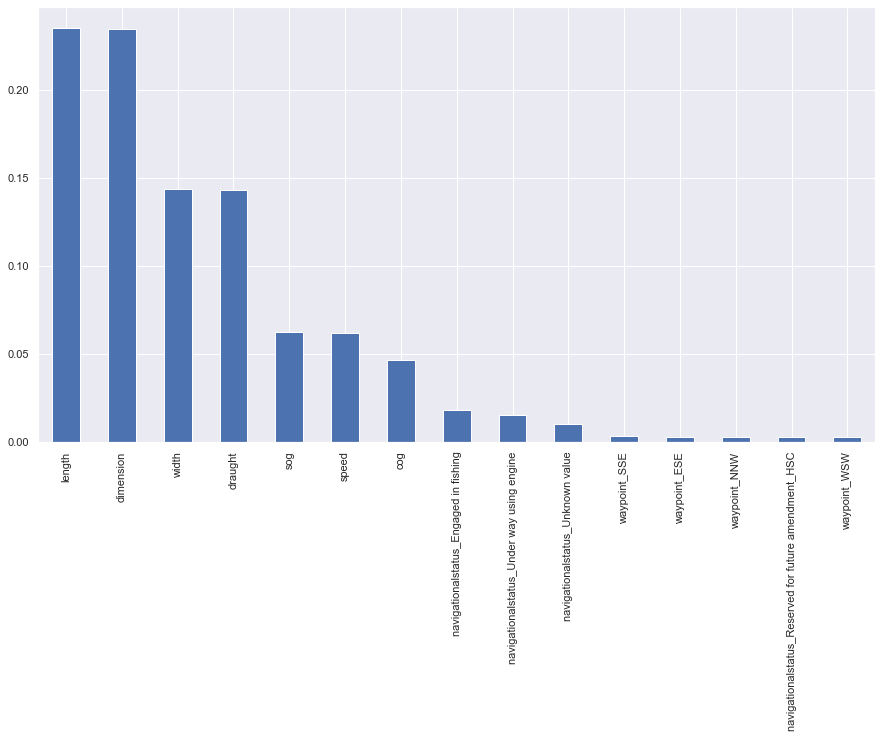

```python
# feature importance
show_feat_imp(model=rf, X=X_test)
```

Feature importance is also similar to decision tree with top features being lenght, dimension, widht and draught.

## 7.4 LightGBM classifier

```python
# random forest classifier object
lgbm = LGBMClassifier(random_state=7)
lgbm.fit(X_train, y_train)

# Prediction on test
lgbm_pred = lgbm.predict(X_test)

# performance of lgbm classifier on test
print(classification_report(y_test, lgbm_pred))
```

```
                  precision    recall  f1-score   support

           Cargo       0.83      0.83      0.83     37524
        Dredging       0.11      0.05      0.07      1062
         Fishing       0.58      0.69      0.63      4986
             HSC       0.00      0.00      0.00       709
 Law enforcement       0.18      0.25      0.21       320
        Military       0.36      0.34      0.35      1416
       Passenger       0.57      0.68      0.62      3298
           Pilot       0.28      0.40      0.33       789
        Pleasure       0.13      0.21      0.16       625
     Port tender       0.00      0.00      0.00        57
        Reserved       0.00      0.00      0.00       144
             SAR       0.07      0.13      0.09       709
         Sailing       0.09      0.09      0.09       370
          Tanker       0.78      0.60      0.68     15452
          Towing       0.03      0.16      0.05       208
Towing long/wide       0.01      0.10      0.02       122
             Tug       0.17      0.12      0.14      1885

        accuracy                           0.68     69676
       macro avg       0.25      0.27      0.25     69676
    weighted avg       0.71      0.68      0.69     69676
```

LightGBM has an accuracy of 68% only and is not performing as well as random forest.

```
cog                                              10759
sog                                              10730
draught                                           6614
length                                            6500
dimension                                         4754
width                                             3477
speed                                             1614
waypoint_SSE                                       508
navigationalstatus_Under way using engine          450
navigationalstatus_Unknown value                   407
waypoint_ESE                                       397
waypoint_WSW                                       370
waypoint_SSW                                       367
waypoint_WNW                                       263
navigationalstatus_Restricted maneuverability      252
dtype: int32
```

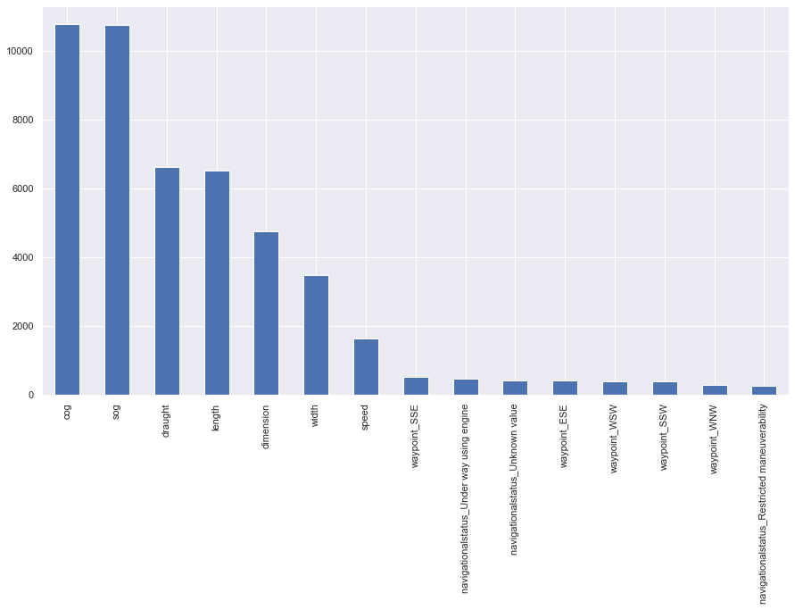

```python
# feature importance
show_feat_imp(model=lgbm, X=X_test)
```

# 7.5 Linear SVM classifier

```python
from sklearn.svm import LinearSVC
lsvm = LinearSVC(random_state=7)
lsvm.fit(X_train, y_train)

# Prediction on test
lsvm_pred = lsvm.predict(X_test)

# performance of lgbm classifier on test
print(classification_report(y_test, lsvm_pred))
```

```
                  precision    recall  f1-score   support

           Cargo       0.67      0.94      0.78     37524
        Dredging       0.28      0.01      0.02      1062
         Fishing       0.74      0.73      0.73      4986
             HSC       0.76      0.74      0.75       709
 Law enforcement       0.00      0.00      0.00       320
        Military       0.17      0.00      0.00      1416
       Passenger       0.63      0.18      0.27      3298
           Pilot       0.67      0.73      0.70       789
        Pleasure       0.51      0.05      0.09       625
     Port tender       0.00      0.00      0.00        57
        Reserved       0.00      0.00      0.00       144
             SAR       0.72      0.60      0.66       709
         Sailing       0.00      0.00      0.00       370
          Tanker       0.68      0.31      0.43     15452
          Towing       0.50      0.02      0.04       208
Towing long/wide       0.00      0.00      0.00       122
             Tug       0.67      0.73      0.70      1885

        accuracy                           0.68     69676
       macro avg       0.41      0.30      0.30     69676
    weighted avg       0.65      0.68      0.62     69676
```

Linear SVM also has an accuracy of 68% similar to LightGBM and is not performing as well as random forest.

# 7.6 Fine tuning Random Forest Classifier

#### Fine tuning hyperparameters of Random Forest Classifier since it is the best performing base model

### 7.6.1 Tuning Random Forest hyperparameters using Grid search CV

```python
rf = RandomForestClassifier(random_state=7)

# specify the hyperparameters and their grid values
# 4 x 3 x 2 = 24 combinations in the grid

param_grid = {
    'n_estimators': [50, 100, 200, 400],
    'max_depth': [6, 10, None],
    'min_samples_split': [2, 5]
}

# using 5-fold cross-validation
grid_search = GridSearchCV(rf, param_grid, cv=5, scoring='f1_macro', return_train_score=True, n_jobs=-1)

start = time.time()
grid_search.fit(X_train, y_train)
end = time.time() - start
print(f"Took {end} seconds")
```

```
Took 2315.9793124198914 seconds
```

```python
print('best parameters from grid search:')
print(grid_search.best_estimator_)

print("best f1_macro score:", grid_search.best_score_)
```

```
best parameters from grid search:
RandomForestClassifier(min_samples_split=5, n_estimators=200, random_state=7)
best f1_macro score: 0.9100639583811295
```

#### Best hyperparameter values are:

max_depth: None  
min_samples_split: 5  
n_estimators: 200

Let's review the scores achieved by all the models in the search grid

```python
# reviewing cv results for different hyperparameter sets
cv_results = pd.DataFrame(grid_search.cv_results_)[['params', 'mean_train_score', 'mean_test_score']]
cv_results["diff, %"] = 100*(cv_results["mean_train_score"]-cv_results["mean_test_score"])/cv_results["mean_train_score"]
pd.set_option('display.max_colwidth', 100)
cv_results.sort_values('mean_test_score', ascending=False)
```

|  | params | mean_train_score | mean_test_score | diff, % |
| --- | --- | --- | --- | --- |
| 22 | {'max_depth': None, 'min_samples_split': 5, 'n_estimators': 200} | 0.97 | 0.91 | 6.60 |
| 21 | {'max_depth': None, 'min_samples_split': 5, 'n_estimators': 100} | 0.97 | 0.91 | 6.57 |
| 23 | {'max_depth': None, 'min_samples_split': 5, 'n_estimators': 400} | 0.97 | 0.91 | 6.65 |
| 20 | {'max_depth': None, 'min_samples_split': 5, 'n_estimators': 50} | 0.97 | 0.91 | 6.59 |
| 18 | {'max_depth': None, 'min_samples_split': 2, 'n_estimators': 200} | 1.00 | 0.91 | 9.15 |
| 19 | {'max_depth': None, 'min_samples_split': 2, 'n_estimators': 400} | 1.00 | 0.91 | 9.19 |
| 17 | {'max_depth': None, 'min_samples_split': 2, 'n_estimators': 100} | 1.00 | 0.91 | 9.23 |
| 16 | {'max_depth': None, 'min_samples_split': 2, 'n_estimators': 50} | 1.00 | 0.91 | 9.28 |
| 11 | {'max_depth': 10, 'min_samples_split': 2, 'n_estimators': 400} | 0.71 | 0.70 | 2.21 |
| 10 | {'max_depth': 10, 'min_samples_split': 2, 'n_estimators': 200} | 0.71 | 0.69 | 2.34 |
| 15 | {'max_depth': 10, 'min_samples_split': 5, 'n_estimators': 400} | 0.71 | 0.69 | 2.40 |
| 14 | {'max_depth': 10, 'min_samples_split': 5, 'n_estimators': 200} | 0.71 | 0.69 | 2.40 |
| 13 | {'max_depth': 10, 'min_samples_split': 5, 'n_estimators': 100} | 0.70 | 0.69 | 2.21 |
| 9 | {'max_depth': 10, 'min_samples_split': 2, 'n_estimators': 100} | 0.70 | 0.68 | 2.74 |
| 12 | {'max_depth': 10, 'min_samples_split': 5, 'n_estimators': 50} | 0.70 | 0.68 | 1.90 |
| 8 | {'max_depth': 10, 'min_samples_split': 2, 'n_estimators': 50} | 0.70 | 0.68 | 2.68 |
| 2 | {'max_depth': 6, 'min_samples_split': 2, 'n_estimators': 200} | 0.46 | 0.46 | 0.27 |
| 6 | {'max_depth': 6, 'min_samples_split': 5, 'n_estimators': 200} | 0.46 | 0.46 | 0.32 |
| 3 | {'max_depth': 6, 'min_samples_split': 2, 'n_estimators': 400} | 0.46 | 0.46 | 0.22 |
| 7 | {'max_depth': 6, 'min_samples_split': 5, 'n_estimators': 400} | 0.46 | 0.46 | 0.25 |
| 1 | {'max_depth': 6, 'min_samples_split': 2, 'n_estimators': 100} | 0.46 | 0.46 | 0.21 |
| 5 | {'max_depth': 6, 'min_samples_split': 5, 'n_estimators': 100} | 0.46 | 0.46 | 0.20 |
| 0 | {'max_depth': 6, 'min_samples_split': 2, 'n_estimators': 50} | 0.45 | 0.45 | 0.05 |
| 4 | {'max_depth': 6, 'min_samples_split': 5, 'n_estimators': 50} | 0.45 | 0.45 | 0.05 |

### 7.6.2 training the RF classifier using best hyperparameters

```python
%%time

# random forest classifier object
rf = RandomForestClassifier(n_estimators=200,\
                            min_samples_split=5,
                            max_depth=None,
                            n_jobs=-1
                           )
rf.fit(X_train, y_train)

# Prediction on test
rf_pred = rf.predict(X_test)

# performance of random forest classifier on test
print(classification_report(y_test, rf_pred))
```

```
                  precision    recall  f1-score   support

           Cargo       0.99      0.99      0.99     37524
        Dredging       0.97      0.96      0.97      1062
         Fishing       0.96      0.97      0.97      4986
             HSC       1.00      0.98      0.99       709
 Law enforcement       1.00      0.98      0.99       320
        Military       0.99      0.98      0.98      1416
       Passenger       0.99      0.98      0.99      3298
           Pilot       0.97      0.98      0.98       789
        Pleasure       0.68      0.68      0.68       625
     Port tender       0.78      0.70      0.74        57
        Reserved       0.92      0.90      0.91       144
             SAR       0.93      0.90      0.92       709
         Sailing       0.63      0.63      0.63       370
          Tanker       0.99      0.97      0.98     15452
          Towing       0.90      0.91      0.91       208
Towing long/wide       0.97      0.90      0.94       122
             Tug       0.99      0.99      0.99      1885

        accuracy                           0.98     69676
       macro avg       0.92      0.91      0.91     69676
    weighted avg       0.98      0.98      0.98     69676

CPU times: total: 3min 45s
Wall time: 32.5 s
```

```
length                                                 0.24
dimension                                              0.23
width                                                  0.15
draught                                                0.15
speed                                                  0.06
sog                                                    0.06
cog                                                    0.04
navigationalstatus_Under way using engine              0.02
navigationalstatus_Engaged in fishing                  0.02
navigationalstatus_Unknown value                       0.01
navigationalstatus_Reserved for future amendment_HSC   0.00
waypoint_SSE                                           0.00
navigationalstatus_Restricted maneuverability          0.00
waypoint_NNW                                           0.00
waypoint_ESE                                           0.00
dtype: float64
```

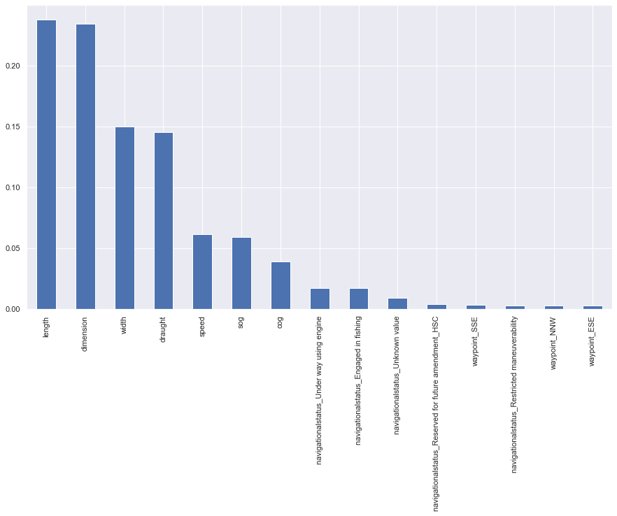

```python
# feature importance
show_feat_imp(model=rf, X=X_test)
```

#### Performance of the tuned random forest model:

1. accuracy: 98%
2. macro avg: 91%
3. weighted avg: 98%

# 8. Conclusion

In this assignment we were sucessfully loaded tha data into dataframe and performed exploratory data analysis. Mutiple libraries including pandas, numpy and matplotlib were used.  
Insights were drawn about the different fields in the data and their relationship with each other.

Missing values were handled and outliers were detected.

In the next section, we performed predictive modeling with the objective of identifying the type of vessel(ship) given it's characteristic features.

For modeling exercise, data was split into train and test sets. Robust-scaling was applied to numerical fields and one hot encoding was done for categorical ones. Different ML algorithms were tested and Random Forest was choosen as the final model based on it's superior accuracy over other models.